# R Example 6: Inverse propensity score weighting

We still use the lalonde data from the MatchIt package and use the propensity score model that we found out in R example 5

```r
library("MatchIt")
data("lalonde")

model <- glm(treat ~ re74 + race + married + I(re74^2) + re74:race, data = lalonde, family = "binomial")
eps <- predict(model, type = "response")

lalonde
```

|  | treat | age | educ | race | married | nodegree | re74 | re75 | re78 |
| --- | --- | --- | --- | --- | --- | --- | --- | --- | --- |
| NSW1 | 1 | 37 | 11 | black | 1 | 1 | 0.00000 | 0.00000 | 9930.04600 |
| NSW2 | 1 | 22 | 9 | hispan | 0 | 1 | 0.00000 | 0.00000 | 3595.89400 |
| NSW3 | 1 | 30 | 12 | black | 0 | 0 | 0.00000 | 0.00000 | 24909.45000 |
| NSW4 | 1 | 27 | 11 | black | 0 | 1 | 0.00000 | 0.00000 | 7506.14600 |
| NSW5 | 1 | 33 | 8 | black | 0 | 1 | 0.00000 | 0.00000 | 289.78990 |
| NSW6 | 1 | 22 | 9 | black | 0 | 1 | 0.00000 | 0.00000 | 4056.49400 |
| NSW7 | 1 | 23 | 12 | black | 0 | 0 | 0.00000 | 0.00000 | 0.00000 |
| NSW8 | 1 | 32 | 11 | black | 0 | 1 | 0.00000 | 0.00000 | 8472.15800 |
| NSW9 | 1 | 22 | 16 | black | 0 | 0 | 0.00000 | 0.00000 | 2164.02200 |
| NSW10 | 1 | 33 | 12 | white | 1 | 0 | 0.00000 | 0.00000 | 12418.07000 |

[output cut: 604 more lines]

Then we perform a first check of the weights by drawing the histogram or boxplot of the weights. At this moment, the figures are not very informative as there are units with extremely large weights.

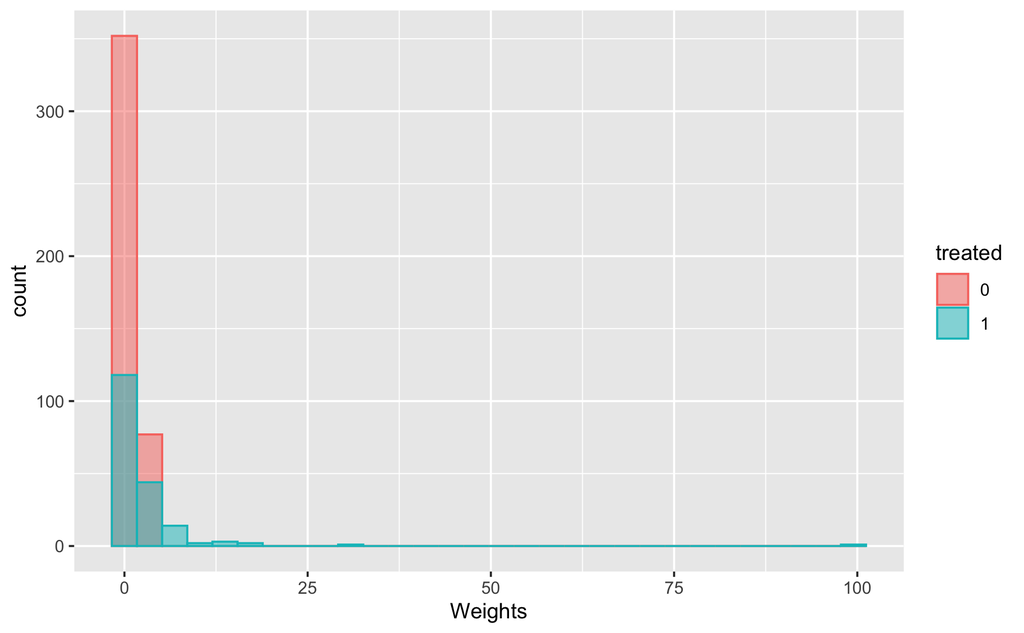

```r
## Calculate the raw weights (before normalization)
## Weights to estimate ATE
n.treated <- sum(lalonde$treat == 1)
n.control <- sum(lalonde$treat == 0)
weights <- ifelse(lalonde$treat == 1, 1/eps, 1/(1 - eps))

## Check the weights histogram
library(ggplot2)
temp.data <- data.frame(weights = weights, treated = as.factor(lalonde$treat))
ggplot(temp.data, aes(x = weights, fill = treated, color = treated)) +
  geom_histogram(alpha = 0.5, position = "identity") +
  xlab("Weights")
```

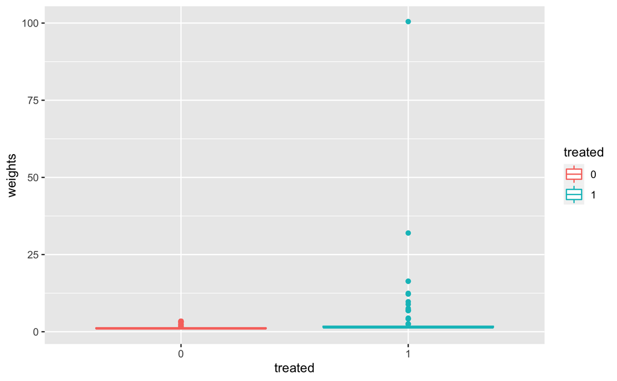

```r
## We can also draw boxplots
ggplot(temp.data, aes(x = treated, y = weights, color = treated)) +
  geom_boxplot()
```

- Check covariate balancing. If we do not perform any trimming and just look at the full data, we can check covariate balancing from the love plot or summary data of the standardized mean difference. Here, we need to write our own function to draw the love plot.

```r
## Need to change race (categorical) into indicators (numerical)
lalonde$black <- lalonde$race == "black"
lalonde$hispan <- lalonde$race == "hispan"
lalonde$white <- lalonde$race == "white"

## Draw love plot
love.plot = function(cov, treat,  ## cov is the matrix of covariates and treat is a vector of treatment assignment
                     weights = rep(1, length(treat)),
                     plot = F)
{

    ## mean with normalized weights \sum w_i x_i / (\sum w_i)
  treat.means <- colSums(cov[treat == 1,] * weights[treat == 1])/sum(weights[treat == 1])
  treat.var <- colSums(t(t(cov[treat == 1,]) - treat.means)^2 *
                          weights[treat == 1])/sum(weights[treat == 1])

  control.means <- colSums(cov[treat == 0,] * weights[treat == 0])/sum(weights[treat == 0])
  control.var <- colSums(t(t(cov[treat == 0,]) - control.means)^2 *
                          weights[treat == 0])/sum(weights[treat == 0])

  ## the standardized mean differences for every covariate
  smd <- (treat.means - control.means)/sqrt((treat.var + control.var)/2)
  names(smd) <- colnames(cov)

  if (plot == T) {
    plot.data <- data.frame(smd = smd, covariates = names(smd))
    range <- max(abs(smd))
    ggplot(plot.data) + geom_point(aes(x = as.numeric(smd), y = covariates)) +
      geom_vline(xintercept = 0) + xlim(-range, range) +
      labs(x = 'Standardized Difference in Means')
  }
  return(smd)
}

colnames(lalonde)
```

```
 [1] "treat"    "age"      "educ"     "race"     "married"  "nodegree" "re74"     "re75"
 [9] "re78"     "black"    "hispan"   "white"
```

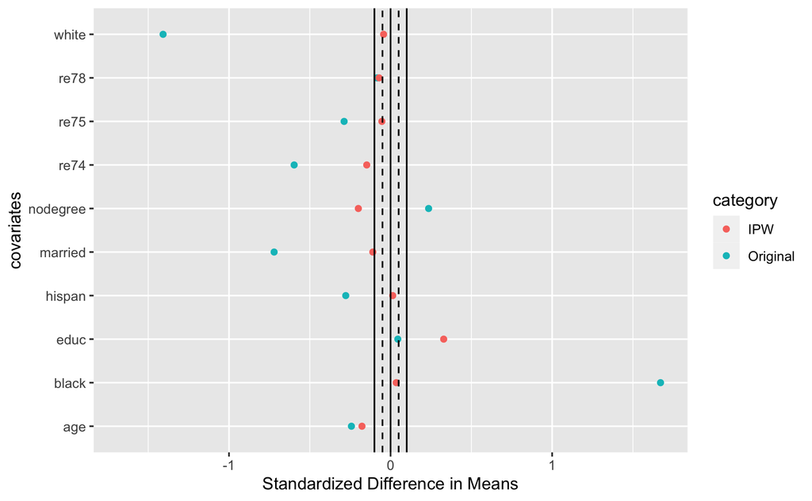

```r
raw.smd <- love.plot(lalonde[, c(2:3, 5:9, 10:12)], lalonde$treat)
weighted.smd <- love.plot(lalonde[, c(2:3, 5:9, 10:12)], lalonde$treat, weights = weights)


plot.data <- data.frame(smd = c(raw.smd, weighted.smd),
                        covariates = c(names(raw.smd), names(weighted.smd)),
                        category = c(rep("Original", length(raw.smd)), rep("IPW", length(weighted.smd))))
range <- max(abs(plot.data$smd))

ggplot(plot.data) + geom_point(aes(x = as.numeric(smd), y = covariates, color = category)) +
      geom_vline(xintercept = c(-0.1, -0.05, 0, 0.05, 0.1),
                 linetype = c("solid", "dashed", "solid", "dashed", "solid")) +
      xlim(-range, range) +
      labs(x = 'Standardized Difference in Means')
```

An alternative approach (no love plot) is to use the survey package to create a summary table

```r
library(survey)
## Another simplier way to check balance (no love plot)
weighteddata <- svydesign(ids = ~ 1, data = lalonde, weights = ~weights)
weightedtable <- svyCreateTableOne(vars = colnames(lalonde)[2:8], strata = "treat", data = weighteddata, test = F)
print(weightedtable, smd = T) ## The first row is the summation of weights
```

```
                      Stratified by treat
                       0                 1                 SMD
  n                     615.43            586.79
  age (mean (SD))        27.01 (10.81)     25.46 (6.20)     0.177
  educ (mean (SD))       10.15 (2.84)      10.95 (1.93)     0.328
  race (%)                                                  0.043
     black               244.6 (39.7)      243.3 (41.5)
     hispan               72.0 (11.7)       71.2 (12.1)
     white               298.8 (48.6)      272.3 (46.4)
  married (mean (SD))     0.41 (0.49)       0.35 (0.48)     0.110
  nodegree (mean (SD))    0.62 (0.49)       0.52 (0.50)     0.199
  re74 (mean (SD))     4508.71 (6374.58) 3678.23 (4795.67)  0.147
  re75 (mean (SD))     2090.95 (3097.31) 1919.51 (3273.26)  0.054
```

Now we perform trimming and check covariate balancing again

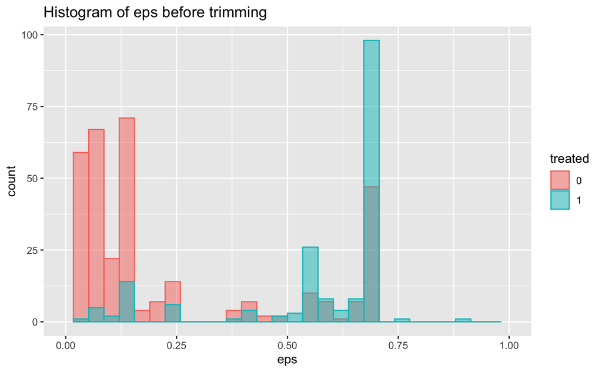

```r
## Histogram of estimated propensity score
temp.data <- data.frame(eps = eps, treated = as.factor(lalonde$treat))
ggplot(temp.data, aes(x = eps, fill = treated, color = treated)) +
  geom_histogram(alpha = 0.5, position = "identity") + xlim(c(0, 1)) +
  ggtitle("Histogram of eps before trimming")
```

```r
rm.idx <- which(eps < 0.1 | eps > 0.9)
## remove control units
length(rm.idx)
```

```
[1] 237
```

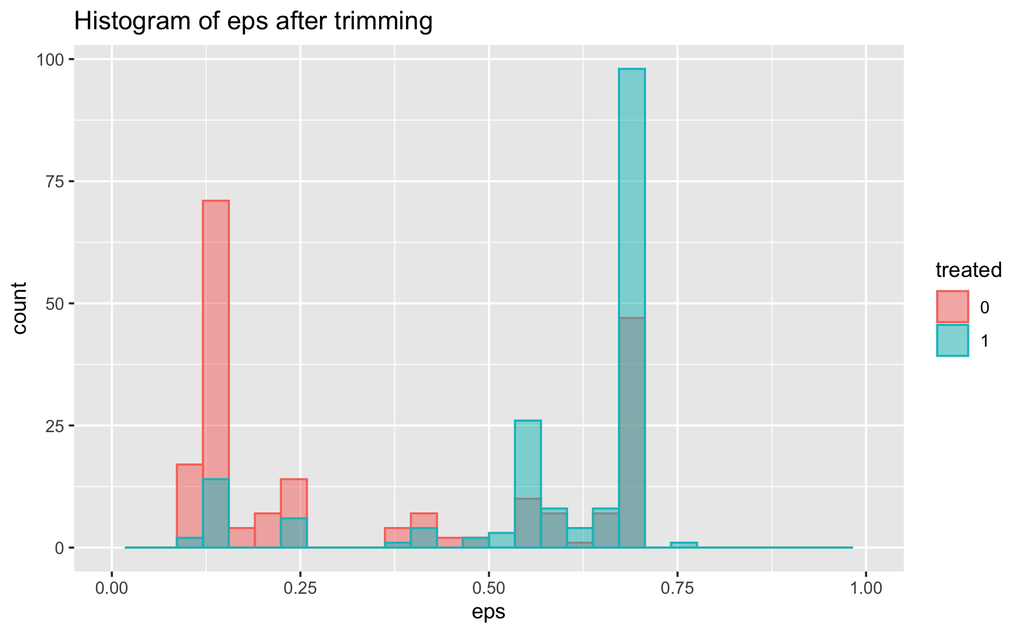

```r
## Check the histogram of eps again
ggplot(temp.data[-rm.idx, ], aes(x = eps, fill = treated, color = treated)) +
  geom_histogram(alpha = 0.5, position = "identity") + xlim(c(0, 1)) +
  ggtitle("Histogram of eps after trimming")
```

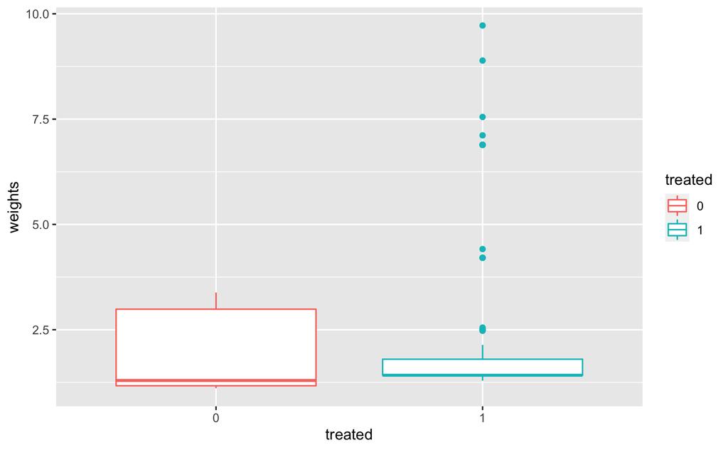

```r
temp.data <- data.frame(weights = weights, treated = as.factor(lalonde$treat))
## We can also draw boxplots
ggplot(temp.data[-rm.idx, ], aes(x = treated, y = weights, color = treated)) +
  geom_boxplot()
```

Check covariate balancing after trimming. Covariate balancing is much better.

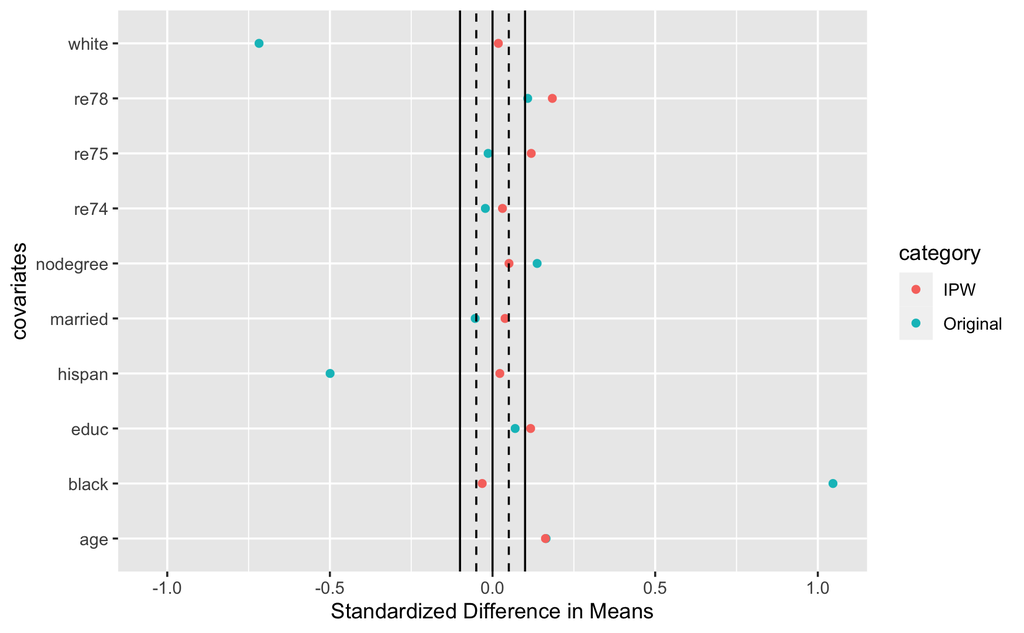

```r
raw.smd <- love.plot(lalonde[-rm.idx, c(2:3, 5:9, 10:12)], lalonde$treat[-rm.idx])
weighted.smd <- love.plot(lalonde[-rm.idx, c(2:3, 5:9, 10:12)], lalonde$treat[-rm.idx],
                          weights = weights[-rm.idx])
plot.data <- data.frame(smd = c(raw.smd, weighted.smd),
                        covariates = c(names(raw.smd), names(weighted.smd)),
                        category = c(rep("Original", length(raw.smd)), rep("IPW", length(weighted.smd))))
range <- max(abs(plot.data$smd))
ggplot(plot.data) + geom_point(aes(x = as.numeric(smd), y = covariates, color = category)) +
      geom_vline(xintercept = c(-0.1, -0.05, 0, 0.05, 0.1),
                 linetype = c("solid", "dashed", "solid", "dashed", "solid")) +
      xlim(-range, range) +
      labs(x = 'Standardized Difference in Means')
```

- Estimate causal effect by weighted least square regression and estimate the variance by Sandwich estimator

```r
lm.result <- lm(re78 ~ treat, weights = weights[-rm.idx], data = lalonde[-rm.idx, ])
summary(lm.result)
```

```
Call:
lm(formula = re78 ~ treat, data = lalonde[-rm.idx, ], weights = weights[-rm.idx])

Weighted Residuals:
   Min     1Q Median     3Q    Max
-17233  -6644  -2553   4239  64304

Coefficients:
            Estimate Std. Error t value Pr(>|t|)
(Intercept)   5135.9      480.0  10.700   <2e-16 ***
treat         1203.2      676.4   1.779   0.0761 .
---
Signif. codes:  0 ‘***’ 0.001 ‘**’ 0.01 ‘*’ 0.05 ‘.’ 0.1 ‘ ’ 1

Residual standard error: 9335 on 375 degrees of freedom
Multiple R-squared:  0.008368,  Adjusted R-squared:  0.005723
F-statistic: 3.164 on 1 and 375 DF,  p-value: 0.07607
```

```r
library(sandwich)
SE <- sqrt(diag(vcovHC(lm.result, type = "HC2")))[2]

## get the 95% CI
result <- c(lm.result$coefficients[2], SE, c(tau_hat- 1.96 * SE, tau_hat + 1.96 * SE))
names(result) <- c("est", "sd", "CI_lower", "CI_upper")
result
```

[output not shown]